# Learn Time Series Week 1

I’m working through the material in the coursera time series analysis course.

Create some data

```r
data<-c(35,8,10,23,42)
```

Five number summary

```r
summary(data)
```

```
   Min. 1st Qu.  Median    Mean 3rd Qu.    Max.
    8.0    10.0    23.0    23.6    35.0    42.0
```

```r
mean(data)
```

```
[1] 23.6
```

```r
sd(data)
```

```
[1] 14.97665
```

Histogram

```r
small.size.dataset<-c(91,49,76,112,97,47, 70, 100, 8, 112, 95, 90, 78, 62, 56, 94, 65, 58, 109, 70, 109, 91, 71, 76, 68, 62, 134, 57, 83, 66)
```

create histogram using base r

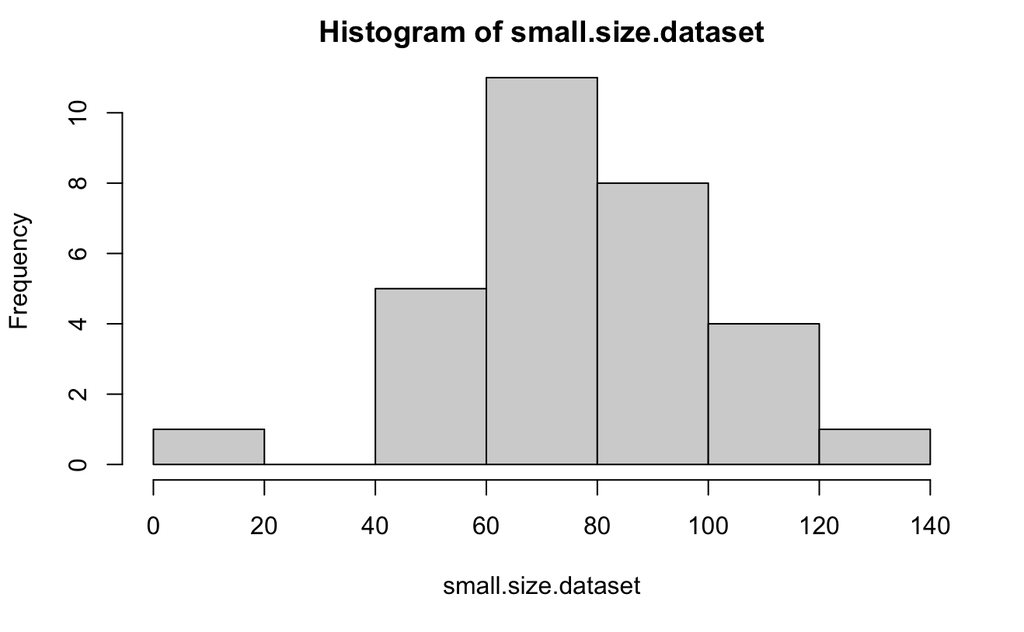

```r
hist(small.size.dataset)
```

Make the plot nicer. * change x-axis label

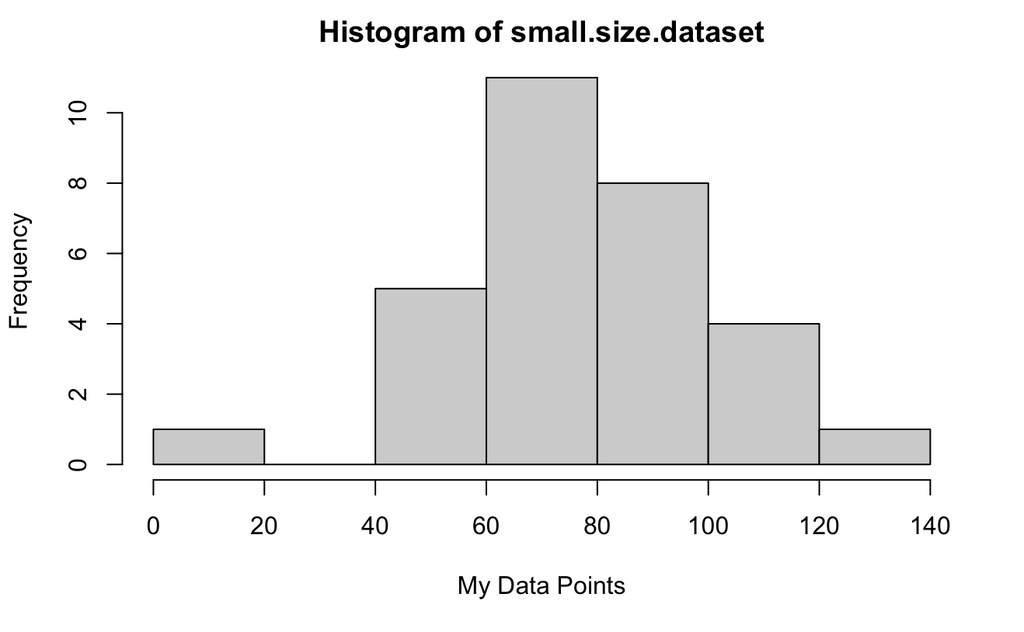

```r
hist(small.size.dataset, xlab = "My Data Points")
```

- Change histogram title

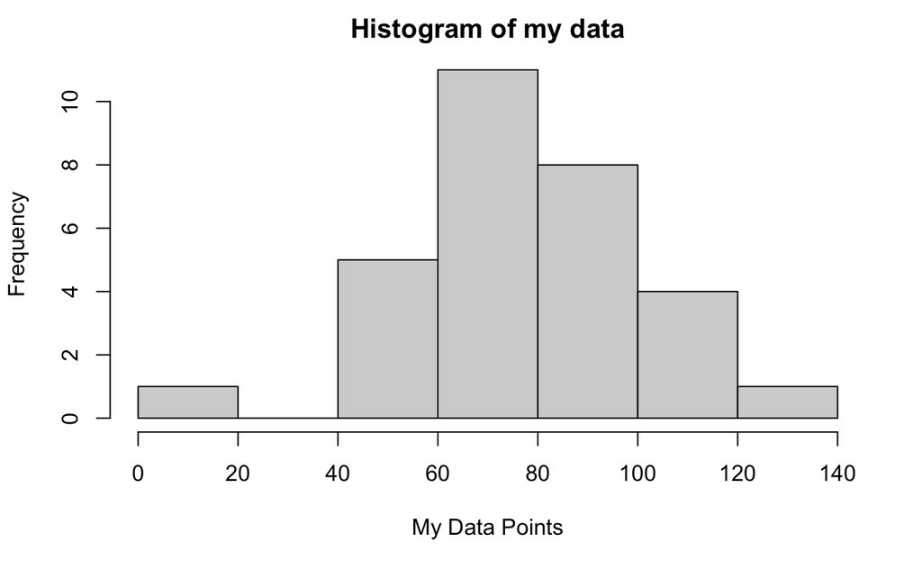

```r
hist(small.size.dataset, xlab = "My Data Points", main = "Histogram of my data")
```

- Change y-axis to probability or density.

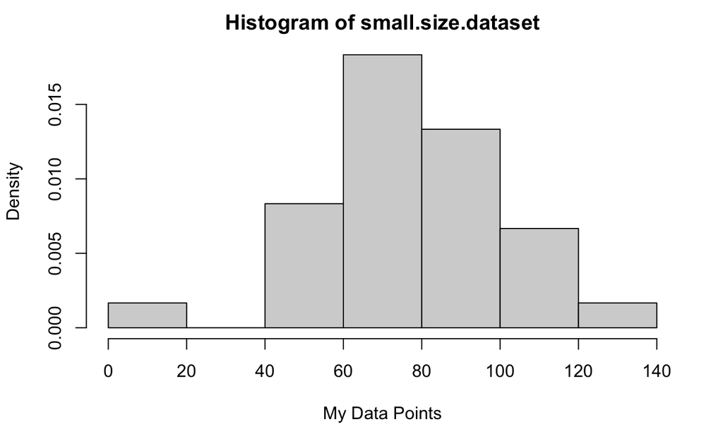

```r
hist(small.size.dataset, xlab = "My Data Points", freq = F)
```

- change colors

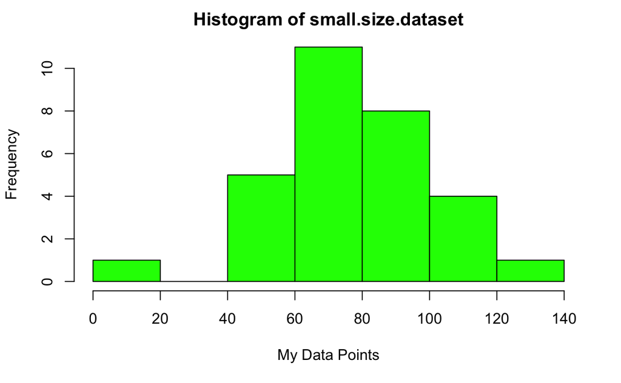

```r
hist(small.size.dataset, xlab = "My Data Points", col = "green")
```

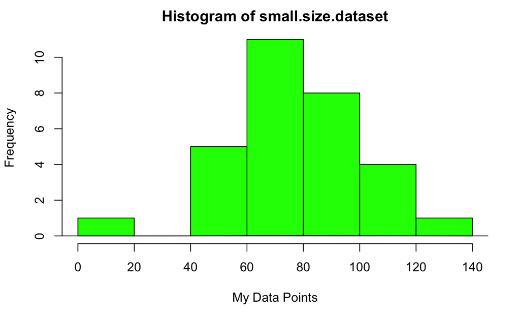

```r
hist(small.size.dataset, xlab = "My Data Points", col = "green")
lines(density(small.size.dataset))
```

Now some basic review of linear regression

```r
#what kind of object is the data?
class(co2)
```

```
[1] "ts"
```

Make a plot

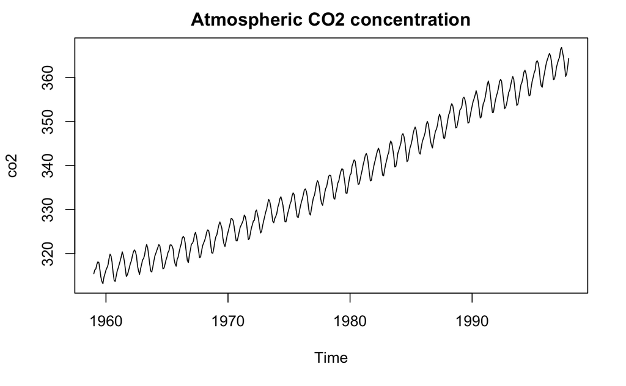

```r
plot(co2, main = "Atmospheric CO2 concentration")
```

Calculate slope and intercept by hand

```r
co2.values<-as.numeric(co2)
co2.times = as.numeric(time(co2))
```

Now calculate sums of squares

```r
SSxx<-sum((co2.times - mean(co2.times))*(co2.times -mean(co2.times)))
SSxy<-sum((co2.values - mean(co2.values))*((co2.times-mean(co2.times))))
```

And now the slope and intercept

```r
slope<-SSxy/SSxx
intercept<-mean(co2.values)-slope*mean(co2.times)
```

So we just made a linear model by hand. R can do it quickly for us:

```r
co2.linear.model<-lm(co2~time(co2))
```

And now place the fitted line ona a graph

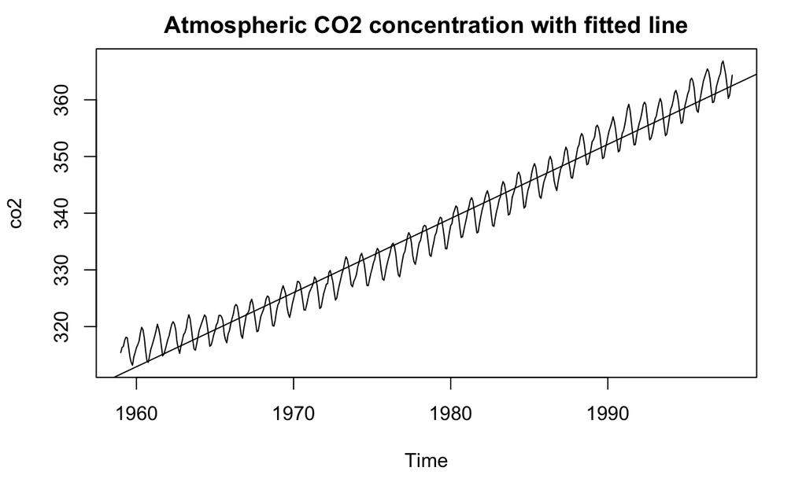

```r
plot(co2, main = "Atmospheric CO2 concentration with fitted line")
abline(co2.linear.model)
```

And calculate the residuals by hand:

```r
co2.fitted.values<-slope*co2.times + intercept
co2.residuals<-co2.values - co2.fitted.values
```

Or we can let R do it for us:

```r
co2.residualsR<-resid(co2.linear.model)
```

An assumption of linear regression is that the residuals are normally distributed. Let’s check, by plotting a histogram (with a large data set) or a normal probability plot (with a smaller data set). Departures from a straight line in a probability plot indicate likely departures from normality.

It is also common to plot residuals against the time (predicted) variable.

```r
par(mfrow = c(1, 3))
hist(co2.residualsR, main = "Histogram of CO2 residuals")
qqnorm(co2.residualsR, main = "Normal probability plot")
```

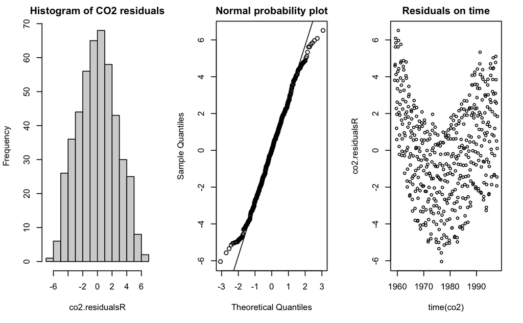

```r
qqline(co2.residualsR)
plot(co2.residualsR ~ time(co2), main = "Residuals on time")
```